# StoreSales

Abhijith Upadhya

2024-10-18

## Introduction

This document presents a comprehensive analysis of sales data, focusing on trends, correlations, and forecasting using R. We will utilize various libraries for data manipulation, visualization, and modeling.

## Setup

First, we need to install and load the necessary packages.

```r
# Load libraries
library(Metrics)
library(zoo)
library(viridis)
library(reshape2)
library(tseries)
library(gridExtra)
library(forecast)
library(xgboost)
library(caret)
library(randomForest)
library(GGally)
library(corrplot)
library(tidyverse)
library(dplyr)
library(ggplot2)
library(lubridate)
library(tidyr)

store <- read.csv('store.csv')
train <- read.csv('train.csv') %>%
  mutate(Date = as.Date(Date)) %>%
  arrange(Date)
```

##Data Loading

We will load the datasets for store and training data.

```r
# Display the first few rows of each dataset
print("Store data:")
```

```
## [1] "Store data:"
```

```r
print(head(store))
```

```
##   Store StoreType Assortment CompetitionDistance CompetitionOpenSinceMonth
## 1     1         c          a                1270                         9
## 2     2         a          a                 570                        11
## 3     3         a          a               14130                        12
## 4     4         c          c                 620                         9
## 5     5         a          a               29910                         4
## 6     6         a          a                 310                        12
##   CompetitionOpenSinceYear Promo2 Promo2SinceWeek Promo2SinceYear
## 1                     2008      0              NA              NA
## 2                     2007      1              13            2010
## 3                     2006      1              14            2011
## 4                     2009      0              NA              NA
## 5                     2015      0              NA              NA
## 6                     2013      0              NA              NA
##     PromoInterval
## 1
## 2 Jan,Apr,Jul,Oct
## 3 Jan,Apr,Jul,Oct
## 4
## 5
## 6
```

```r
print("\nTrain data:")
```

```
## [1] "\nTrain data:"
```

```r
print(head(train))
```

```
##   Store DayOfWeek       Date Sales Customers Open Promo StateHoliday
## 1     1         2 2013-01-01     0         0    0     0            a
## 2     2         2 2013-01-01     0         0    0     0            a
## 3     3         2 2013-01-01     0         0    0     0            a
## 4     4         2 2013-01-01     0         0    0     0            a
## 5     5         2 2013-01-01     0         0    0     0            a
## 6     6         2 2013-01-01     0         0    0     0            a
##   SchoolHoliday
## 1             1
## 2             1
## 3             1
## 4             1
## 5             1
## 6             1
```

##Data Preparation

Next, we merge the training data with store data and extract year and month from the date.

```r
# Merge train and store data
train_store_joined <- inner_join(train, store, by = "Store")

# Extract month and year from the date
train_store_joined <- train_store_joined %>%
  mutate(Year = year(Date),
         Month = month(Date))
```

##Sales Summary by Month

We summarize sales data by month and create a line plot with error bars.

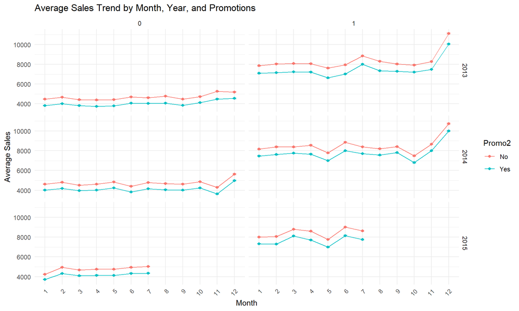

```r
sales_summary <- train_store_joined %>%
  group_by(Year, Month, Promo, Promo2) %>%
  summarise(
    mean_sales = mean(Sales, na.rm = TRUE),
    se_sales = sd(Sales, na.rm = TRUE) / sqrt(n()),
    .groups = 'drop'
  )

# Create the line plot with error bars
sales_trend_plot <- ggplot(sales_summary, aes(x = factor(Month), y = mean_sales, group = interaction(Year, Promo2), color = factor(Promo2))) +
  geom_line() +
  geom_point() +
  geom_errorbar(aes(ymin = mean_sales - se_sales, ymax = mean_sales + se_sales), width = 0.2) +
  facet_grid(Year ~ Promo) +
  labs(title = "Average Sales Trend by Month, Year, and Promotions",
       x = "Month", y = "Average Sales", color = "Promo2") +
  theme_minimal() +
  theme(axis.text.x = element_text(angle = 45, hjust = 1)) +
  scale_color_discrete(name = "Promo2", labels = c("No", "Yes"))

# Print the plot
print(sales_trend_plot)
```

##Sales Summary by Day of Week

Next, we analyze sales trends over the days of the week.

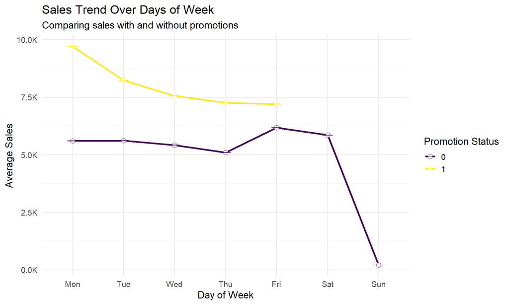

```r
sales_summary_weekday <- train_store_joined %>%
  group_by(DayOfWeek, Promo) %>%
  summarise(
    mean_sales = mean(Sales, na.rm = TRUE),
    se_sales = sd(Sales, na.rm = TRUE) / sqrt(n()),
    .groups = 'drop'
  )

# Create the plot for sales trend over days of week
sales_trend_weekday_plot <- ggplot(sales_summary_weekday, aes(x = factor(DayOfWeek), y = mean_sales, group = factor(Promo), color = factor(Promo))) +
  geom_line(size = 1.2) +
  geom_point(size = 3, shape = 21, fill = "white") +
  geom_errorbar(aes(ymin = mean_sales - se_sales, ymax = mean_sales + se_sales), width = 0.2, alpha = 0.7) +
  labs(
    title = "Sales Trend Over Days of Week",
    subtitle = "Comparing sales with and without promotions",
    x = "Day of Week",
    y = "Average Sales",
    color = "Promotion Status"
  ) +
  scale_x_discrete(labels = c("Mon", "Tue", "Wed", "Thu", "Fri", "Sat", "Sun")) +
  scale_y_continuous(labels = scales::comma_format(scale = 1e-3, suffix = "K")) +
  scale_color_viridis(discrete = TRUE) +
  theme_minimal(base_size = 14)

# Print the plot
print(sales_trend_weekday_plot)
```

##Correlation Analysis

We analyze correlations between key features using a heatmap.

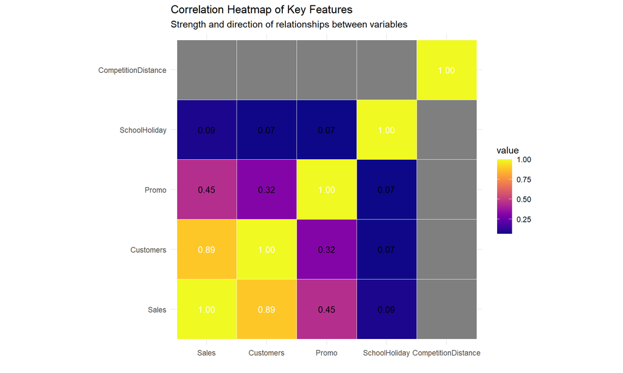

```r
correlation_matrix <- train_store_joined %>%
  select(Sales, Customers, Promo, SchoolHoliday, CompetitionDistance) %>%
  cor()

corr_melted <- melt(correlation_matrix)

# Create the correlation heatmap
correlation_plot <- ggplot(corr_melted, aes(x = Var1, y = Var2, fill = value)) +
  geom_tile(color = "white") +
  geom_text(aes(label = sprintf("%.2f", value)),
            color = ifelse(abs(corr_melted$value) > 0.5, "white", "black"),
            size=3.5) +
  scale_fill_viridis(option="C") +
  coord_equal() +
  theme_minimal() +
  labs(
    title="Correlation Heatmap of Key Features",
    subtitle="Strength and direction of relationships between variables",
    x="",
    y=""
  )

# Print the plot
print(correlation_plot)
```

##Time Series Analysis

We will perform time series analysis on weekly sales.

#Weekly Sales Calculation

```r
sales_a <- train %>%
  filter(Store == 2) %>%
  select(Date, Sales) %>%
  arrange(Date)

weekly_sales_a <- sales_a %>%
  mutate(week=as.Date(cut(Date, breaks="week"))) %>%
  group_by(week) %>%
  summarise(Sales=sum(Sales))
```

##Stationarity Check

We will check for stationarity in our time series data.

```r
test_stationarity <- function(timeseries) {

   # Perform Dickey-Fuller test
   adf_test <- adf.test(timeseries$Sales)

   # Output results of Dickey-Fuller test
   print("Results of Dickey-Fuller Test:")
   print(paste("ADF Statistic: ", adf_test$statistic))
   print(paste("p-value: ", adf_test$p.value))

   if(adf_test$p.value < 0.05) {
     print("Data is stationary (Reject the null hypothesis)")
   } else {
     print("Data is not stationary (Fail to reject the null hypothesis)")
   }
}

# Testing stationarity for Store Type 'a'
test_stationarity(weekly_sales_a)
```

```
## [1] "Results of Dickey-Fuller Test:"
## [1] "ADF Statistic:  -4.52448341660804"
## [1] "p-value:  0.01"
## [1] "Data is stationary (Reject the null hypothesis)"
```

##Decomposition Plot

We will visualize the trend and seasonality in our time series data.

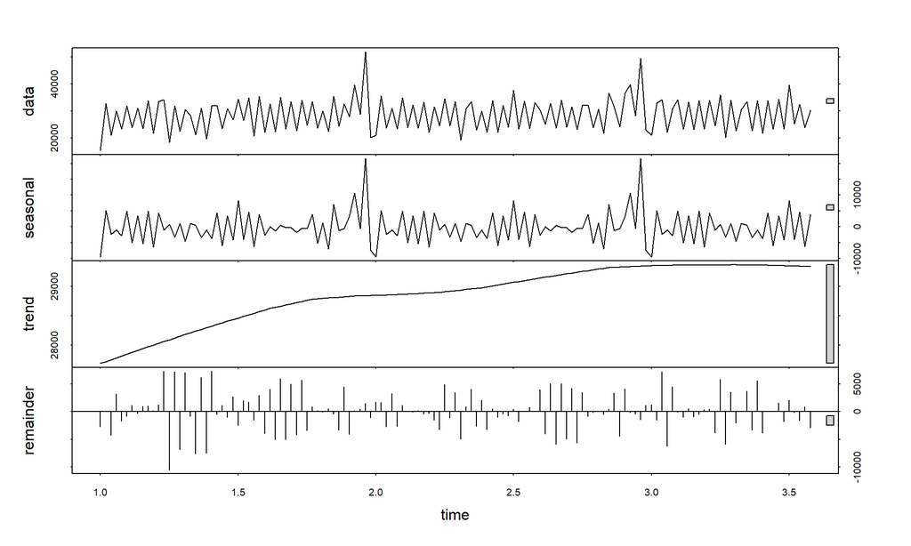

```r
plot_timeseries <- function(sales) {
   ts_data <- ts(sales$Sales, frequency=52)

   # Perform decomposition
   decomp <- stl(ts_data,s.window="periodic")

   # Plot decomposition
   plot(decomp)
}

# Plot decomposition for Store Type 'a'
plot_timeseries(weekly_sales_a)
```

##ARIMA Model Fitting

We will fit an ARIMA model to forecast future sales.

```r
weekly_sales_ts <- ts(weekly_sales_a$Sales, frequency=52)

fit_arima <- auto.arima(weekly_sales_ts)

# Print ARIMA model summary
summary(fit_arima)
```

```
## Series: weekly_sales_ts
## ARIMA(2,0,0)(0,1,0)[52] with drift
##
## Coefficients:
##           ar1      ar2    drift
##       -0.8976  -0.1884  11.4142
## s.e.   0.1097   0.1094   3.6318
##
## sigma^2 = 13166186:  log likelihood = -797.02
## AIC=1602.03   AICc=1602.55   BIC=1611.71
##
## Training set error measures:
##                    ME     RMSE      MAE        MPE     MAPE      MASE
## Training set 34.68796 2793.239 1636.826 -0.2642338 5.757394 0.4229341
##                    ACF1
## Training set 0.00370443
```

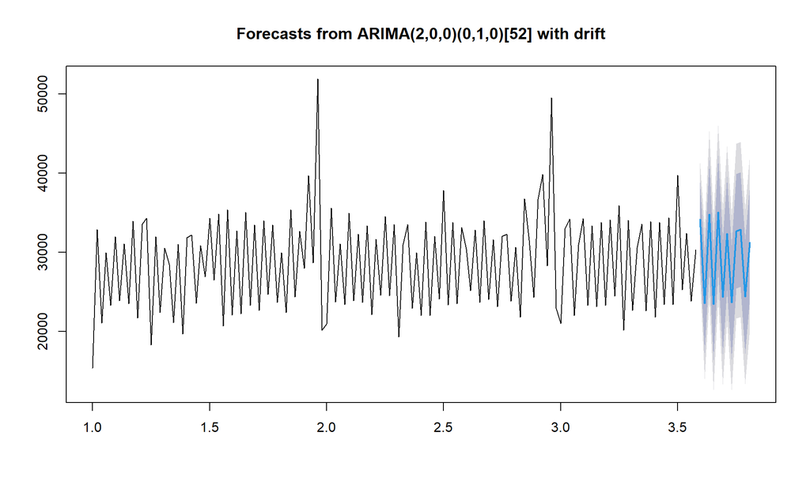

```r
forecasted_sales <- forecast(fit_arima,h=12)

# Plot the forecasted sales
plot(forecasted_sales)
```